# Reproducible Research: Peer Assessment 1

## Loading and preprocessing the data

```r
suppressMessages(library(dplyr))
library(dplyr)
data<-read.csv("activity.csv")
head(data)
```

```
##   steps       date interval
## 1    NA 2012-10-01        0
## 2    NA 2012-10-01        5
## 3    NA 2012-10-01       10
## 4    NA 2012-10-01       15
## 5    NA 2012-10-01       20
## 6    NA 2012-10-01       25
```

## What is mean total number of steps taken per day?

```r
library(ggplot2)
data_by_days <- group_by(data, date)
steps_per_day <- summarise(data_by_days,
                           step_count = sum(steps, na.rm = TRUE)
                           )
summary(steps_per_day)
```

```
##          date      step_count
##  2012-10-01: 1   Min.   :    0
##  2012-10-02: 1   1st Qu.: 6778
##  2012-10-03: 1   Median :10395
##  2012-10-04: 1   Mean   : 9354
##  2012-10-05: 1   3rd Qu.:12811
##  2012-10-06: 1   Max.   :21194
##  (Other)   :55
```

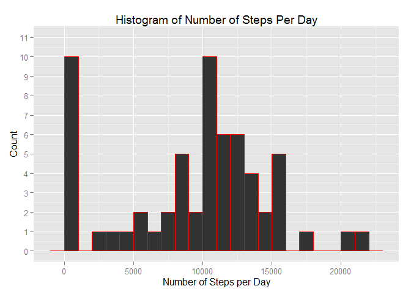

```r
median_of_steps <- median(steps_per_day$step_count)
mean_of_steps <- mean(steps_per_day$step_count)

m <- ggplot(steps_per_day, aes(x = step_count))
m + geom_histogram(color="red", binwidth = 1000)+
        labs(title = "Histogram of Number of Steps Per Day") +
        labs(x = "Number of Steps per Day", y ="Count")+
        scale_y_continuous(breaks=c(0,1,2,3,4,5,6,7,8,9,10,11),limits=c(0,11))
```

The **mean** of the total number of steps taken per day is 9354.2.

The **median** of the the total number of steps taken per day is 10395.

## What is the average daily activity pattern?

```r
library(lubridate)
options(lubridate.verbose = FALSE)
data_by_5s <- group_by(data, interval)
head(data_by_5s)
```

```
## Source: local data frame [6 x 3]
## Groups: interval
##
##   steps       date interval
## 1    NA 2012-10-01        0
## 2    NA 2012-10-01        5
## 3    NA 2012-10-01       10
## 4    NA 2012-10-01       15
## 5    NA 2012-10-01       20
## 6    NA 2012-10-01       25
```

```r
steps_by_5 <- summarise(data_by_5s,
                           step_avg = mean(steps, na.rm = TRUE)
                           )
head(steps_by_5)
```

```
## Source: local data frame [6 x 2]
##
##   interval  step_avg
## 1        0 1.7169811
## 2        5 0.3396226
## 3       10 0.1320755
## 4       15 0.1509434
## 5       20 0.0754717
## 6       25 2.0943396
```

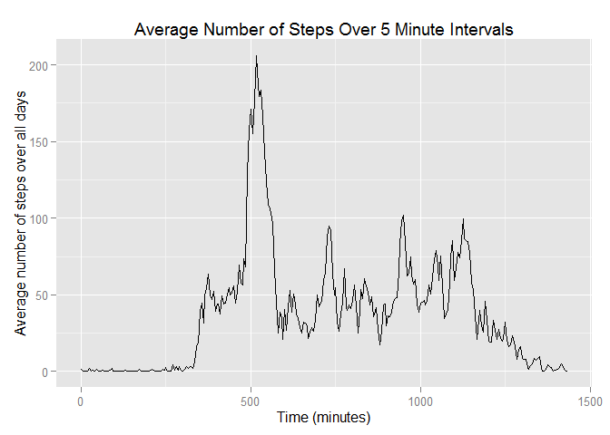

```r
df_with_time <- mutate(steps_by_5,
          time = as.duration(hms(paste(interval %/% 100, interval %% 100, 0)))/60
          )
all_the_best <- summarise(df_with_time, most_steps = max(step_avg),
                          best_interval = interval[which.max(step_avg)]
                         )
g <- ggplot(df_with_time, aes(time, step_avg))
g+geom_line()+
        labs(title = "Average Number of Steps Over 5 Minute Intervals") +
        labs(x = "Time (minutes)", y ="Average number of steps over all days")
```

Interval **835** contains the maximum number of steps on average (206.2) across all the days in the dataset.

**Note:** Interval 835 corresponds to 8:35, which in turn is the 515-th minute of the day.

## Imputing missing values

```r
data_size <- nrow(data)
day_span <- nrow(steps_per_day)
```

The data spans 61 days and there are 17568 entries in the dataset, however there are quite a few missing entries coded as NA. Dropping the rows containing na’s:

```r
data_no_na <- data[complete.cases(data),]
size_no_na <- nrow(data_no_na)
dropped_rows_number <- data_size - size_no_na
```

So the total number of rows with missing values (i.e. NA’s) is 2304.

I will replace the missing NA’s by mean for that particular 5 minute interval.

```r
#creating a vector of averages to be inserted into the original data frame
avg_steps <- rep(steps_by_5$step_avg, times = 61)
#inserting avg_steps and a replicate column, col_x into data and calling it
# data_plus
data_plus <- mutate(data, avgs = avg_steps, col_x = steps)

#creating a boolean vector for the locations of NA's in the original data frame
na_boolean <- is.na(data$steps)

#mutating col_x by replacing its NA's with the appropriate averages
data_plus$col_x[na_boolean] = data_plus$avgs[na_boolean]

#examining data_plus by viewing a selection of rows - some of which contain NA's
#and some of which do not.
data_plus[285:295,]
```

```
##     steps       date interval      avgs     col_x
## 285    NA 2012-10-01     2340 3.3018868 3.3018868
## 286    NA 2012-10-01     2345 0.6415094 0.6415094
## 287    NA 2012-10-01     2350 0.2264151 0.2264151
## 288    NA 2012-10-01     2355 1.0754717 1.0754717
## 289     0 2012-10-02        0 1.7169811 0.0000000
## 290     0 2012-10-02        5 0.3396226 0.0000000
## 291     0 2012-10-02       10 0.1320755 0.0000000
## 292     0 2012-10-02       15 0.1509434 0.0000000
## 293     0 2012-10-02       20 0.0754717 0.0000000
## 294     0 2012-10-02       25 2.0943396 0.0000000
## 295     0 2012-10-02       30 0.5283019 0.0000000
```

Whew. Replacement is successful: *col_x* of *data_plus* is corresponds to the *steps* column of the original data frame, whose NA entries have been replaced by the average for that particular 5 minute interval.

Next, I will create a histogram of this new data (*col_x*) with the missing data filled in.

```r
data_plus_by_days <- group_by(data_plus, date)
steps_per_day_plus <- summarise(data_plus_by_days,
                           step_count_plus = sum(col_x)
                           )
head(steps_per_day_plus)
```

```
## Source: local data frame [6 x 2]
##
##         date step_count_plus
## 1 2012-10-01        10766.19
## 2 2012-10-02          126.00
## 3 2012-10-03        11352.00
## 4 2012-10-04        12116.00
## 5 2012-10-05        13294.00
## 6 2012-10-06        15420.00
```

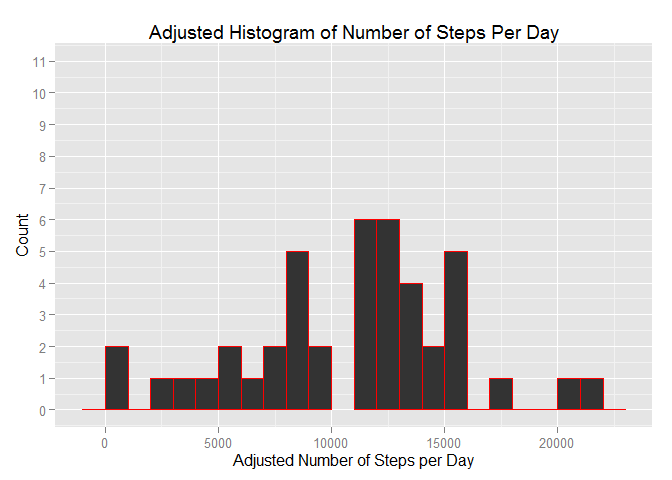

```r
median_of_steps_plus <- median(steps_per_day_plus$step_count_plus)
mean_of_steps_plus <- mean(steps_per_day_plus$step_count_plus)
med <- as.integer(median_of_steps_plus)
m <- ggplot(steps_per_day_plus, aes(x = step_count_plus))
m + geom_histogram(color="red", binwidth = 1000)+
        labs(title = "Adjusted Histogram of Number of Steps Per Day") +
        labs(x = "Adjusted Number of Steps per Day", y ="Count")+
        scale_y_continuous(breaks=c(0,1,2,3,4,5,6,7,8,9,10,11),limits=c(0,11))
```

The **mean** of the adjusted total number of steps taken per day is 10766.

The **median** of the the adjusted total number of steps taken per day is 10766.

After imputing the missing values both the mean and the median have increased and are now equal. It seems that the total number of steps per day has on average increased after replacing the missing values by the corresponding 5 minute interval averages.

## Are there differences in activity patterns between weekdays and weekends?

```r
#Creating a vector of days corresponding to the dates in the data frame
v <- weekdays(as.Date(data$date))

#adding
data_plus<- mutate(data_plus, days = v )

#checking
head(data_plus)
```

```
##   steps       date interval      avgs     col_x   days
## 1    NA 2012-10-01        0 1.7169811 1.7169811 Monday
## 2    NA 2012-10-01        5 0.3396226 0.3396226 Monday
## 3    NA 2012-10-01       10 0.1320755 0.1320755 Monday
## 4    NA 2012-10-01       15 0.1509434 0.1509434 Monday
## 5    NA 2012-10-01       20 0.0754717 0.0754717 Monday
## 6    NA 2012-10-01       25 2.0943396 2.0943396 Monday
```

Now, on to create the new factor variables *weekday* and *weekend*.

```r
weekdays = c("Monday", "Tuesday", "Wednesday", "Thursday", "Friday")
weekenddays = c("Saturday", "Sunday")

#adding a for now dummy column to data_plus
data_plus <- mutate(data_plus, new_col = rep(c("weekend"), times = nrow(data_plus)))

#checking
head(data_plus, 4)
```

```
##   steps       date interval      avgs     col_x   days new_col
## 1    NA 2012-10-01        0 1.7169811 1.7169811 Monday weekend
## 2    NA 2012-10-01        5 0.3396226 0.3396226 Monday weekend
## 3    NA 2012-10-01       10 0.1320755 0.1320755 Monday weekend
## 4    NA 2012-10-01       15 0.1509434 0.1509434 Monday weekend
```

```r
#adjusting the newly added dummy column so it contains the correct info
data_plus$new_col[(data_plus$days %in% weekdays)] = "weekday"

#checking the result using some range where both weekdays and weekends appear
data_plus[3453:3458,]
```

```
##      steps       date interval      avgs col_x     days new_col
## 3453     0 2012-10-12     2340 3.3018868     0   Friday weekday
## 3454     0 2012-10-12     2345 0.6415094     0   Friday weekday
## 3455     0 2012-10-12     2350 0.2264151     0   Friday weekday
## 3456     0 2012-10-12     2355 1.0754717     0   Friday weekday
## 3457     0 2012-10-13        0 1.7169811     0 Saturday weekend
## 3458     0 2012-10-13        5 0.3396226     0 Saturday weekend
```

```r
#adding a factor variable column to the df

data_plus$new_factor<-factor(data_plus$new_col)

#checking

str(data_plus$new_factor)
```

```
##  Factor w/ 2 levels "weekday","weekend": 1 1 1 1 1 1 1 1 1 1 ...
```

```r
data_plus[3453:3458,]
```

```
##      steps       date interval      avgs col_x     days new_col new_factor
## 3453     0 2012-10-12     2340 3.3018868     0   Friday weekday    weekday
## 3454     0 2012-10-12     2345 0.6415094     0   Friday weekday    weekday
## 3455     0 2012-10-12     2350 0.2264151     0   Friday weekday    weekday
## 3456     0 2012-10-12     2355 1.0754717     0   Friday weekday    weekday
## 3457     0 2012-10-13        0 1.7169811     0 Saturday weekend    weekend
## 3458     0 2012-10-13        5 0.3396226     0 Saturday weekend    weekend
```

```r
grouped <- group_by(data_plus, new_factor, interval)
grouped_steps <- summarise(grouped, step_averages = mean(steps, na.rm = TRUE))
grouped_steps
```

```
## Source: local data frame [576 x 3]
## Groups: new_factor
##
##    new_factor interval step_averages
## 1     weekday        0     2.3333333
## 2     weekday        5     0.4615385
## 3     weekday       10     0.1794872
## 4     weekday       15     0.2051282
## 5     weekday       20     0.1025641
## 6     weekday       25     1.5128205
## 7     weekday       30     0.7179487
## 8     weekday       35     1.1794872
## 9     weekday       40     0.0000000
## 10    weekday       45     1.8461538
## ..        ...      ...           ...
```

```r
#adding a time column measured in minutes to grouped steps
grouped_steps<- mutate(grouped_steps,
          time = as.duration(hms(paste(interval %/% 100, interval %% 100, 0)))/60
          )


#checking
grouped_steps[23:33,]
```

```
## Source: local data frame [11 x 4]
## Groups: new_factor
##
##    new_factor interval step_averages time
## 1     weekday      150     0.3589744  110
## 2     weekday      155     0.0000000  115
## 3     weekday      200     0.0000000  120
## 4     weekday      205     0.0000000  125
## 5     weekday      210     1.4358974  130
## 6     weekday      215     0.0000000  135
## 7     weekday      220     0.0000000  140
## 8     weekday      225     0.1794872  145
## 9     weekday      230     0.0000000  150
## 10    weekday      235     0.3076923  155
## 11    weekday      240     0.0000000  160
```

```r
#creating the plots
weekday_group <- subset(grouped_steps, new_factor == "weekday" )
weekday_group
```

```
## Source: local data frame [288 x 4]
## Groups: new_factor
##
##    new_factor interval step_averages time
## 1     weekday        0     2.3333333    0
## 2     weekday        5     0.4615385    5
## 3     weekday       10     0.1794872   10
## 4     weekday       15     0.2051282   15
## 5     weekday       20     0.1025641   20
## 6     weekday       25     1.5128205   25
## 7     weekday       30     0.7179487   30
## 8     weekday       35     1.1794872   35
## 9     weekday       40     0.0000000   40
## 10    weekday       45     1.8461538   45
## ..        ...      ...           ...  ...
```

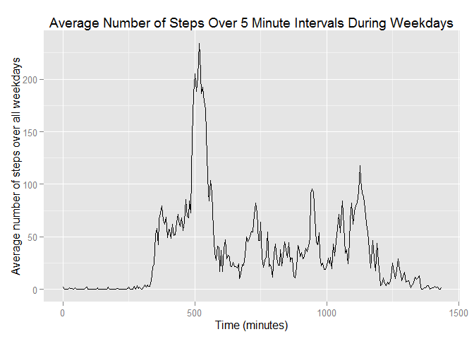

```r
g2 <- ggplot(weekday_group, aes(time, step_averages))
g2+geom_line()+
        labs(title = "Average Number of Steps Over 5 Minute Intervals During Weekdays") +
        labs(x = "Time (minutes)", y ="Average number of steps over all weekdays")
```

```r
weekend_group <- subset(grouped_steps, new_factor == "weekend")
weekend_group
```

```
## Source: local data frame [288 x 4]
## Groups: new_factor
##
##    new_factor interval step_averages time
## 1     weekend        0     0.0000000    0
## 2     weekend        5     0.0000000    5
## 3     weekend       10     0.0000000   10
## 4     weekend       15     0.0000000   15
## 5     weekend       20     0.0000000   20
## 6     weekend       25     3.7142857   25
## 7     weekend       30     0.0000000   30
## 8     weekend       35     0.0000000   35
## 9     weekend       40     0.0000000   40
## 10    weekend       45     0.4285714   45
## ..        ...      ...           ...  ...
```

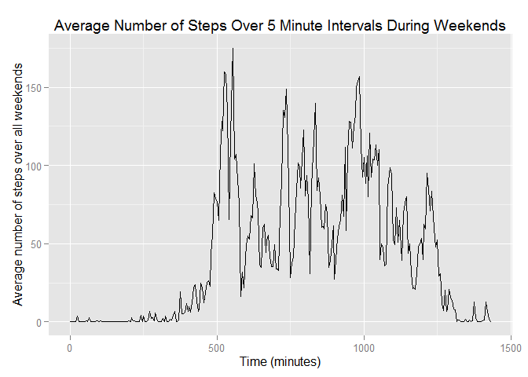

```r
g2 <- ggplot(weekend_group, aes(time, step_averages))
g2+geom_line()+
        labs(title = "Average Number of Steps Over 5 Minute Intervals During Weekends") +
        labs(x = "Time (minutes)", y ="Average number of steps over all weekends")
```